# DATA 621 HW4 WA

## 3. BUILD MODELS:

### 3.1 Multiple Linear Regression Models:

#### 3.1.1 Model 1: Using original varaibles

```r
# Multiple Linear Regression - Model 1 (using selected transformed variables)
model_1 <- lm(TARGET_AMT_LOG ~ AGE + CAR_AGE + BLUEBOOK + KIDSDRIV_LOG + HOMEKIDS_LOG + MVR_PTS, data = insurance_training)
summary(model_1)
```

```
##
## Call:
## lm(formula = TARGET_AMT_LOG ~ AGE + CAR_AGE + BLUEBOOK + KIDSDRIV_LOG +
##     HOMEKIDS_LOG + MVR_PTS, data = insurance_training)
##
## Residuals:
##    Min     1Q Median     3Q    Max
## -6.402 -2.246 -1.508  3.252 10.166
##
## Coefficients:
##                Estimate Std. Error t value Pr(>|t|)
## (Intercept)   2.837e+00  2.707e-01  10.482  < 2e-16 ***
## AGE          -1.564e-02  5.462e-03  -2.863  0.00421 **
## CAR_AGE      -4.307e-02  7.315e-03  -5.887 4.09e-09 ***
## BLUEBOOK     -2.588e-05  4.942e-06  -5.237 1.68e-07 ***
## KIDSDRIV_LOG  7.758e-01  1.633e-01   4.752 2.05e-06 ***
## HOMEKIDS_LOG  2.967e-01  9.841e-02   3.015  0.00258 **
## MVR_PTS       3.599e-01  1.888e-02  19.060  < 2e-16 ***
## ---
## Signif. codes:  0 '***' 0.001 '**' 0.01 '*' 0.05 '.' 0.1 ' ' 1
##
## Residual standard error: 3.528 on 7638 degrees of freedom
##   (516 observations deleted due to missingness)
## Multiple R-squared:  0.07448,    Adjusted R-squared:  0.07375
## F-statistic: 102.4 on 6 and 7638 DF,  p-value: < 2.2e-16
```

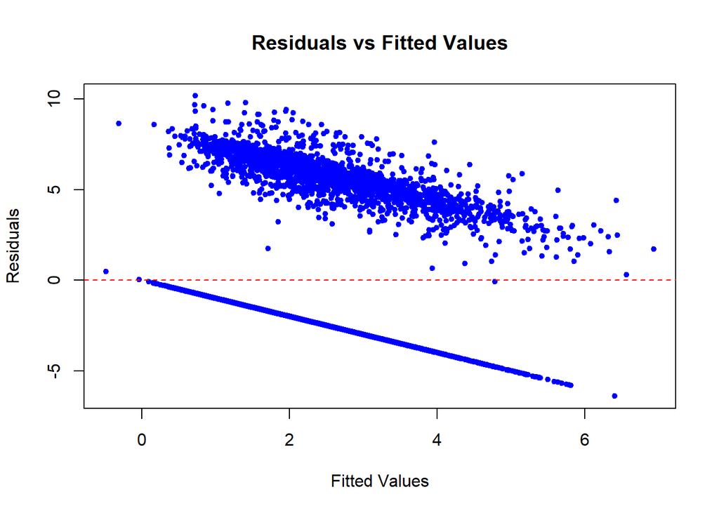

```r
# Plot Residuals vs Fitted Values
plot(model_1$fitted.values, resid(model_1),
     xlab = "Fitted Values",
     ylab = "Residuals",
     main = "Residuals vs Fitted Values",
     pch = 20, col = "blue")
abline(h = 0, col = "red", lty = 2)
```

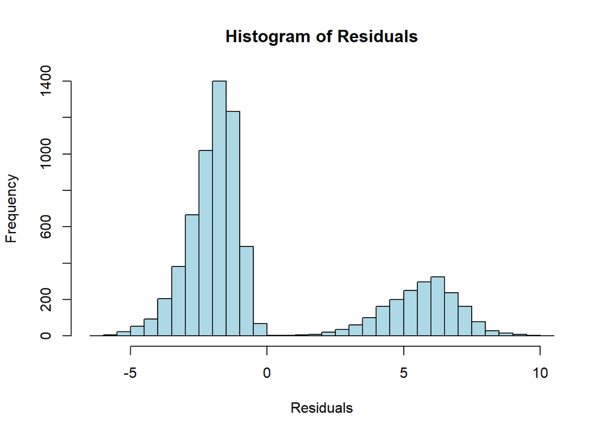

```r
# Histogram of Residuals
hist(resid(model_1),
     breaks = 30,
     main = "Histogram of Residuals",
     xlab = "Residuals",
     col = "lightblue")
```

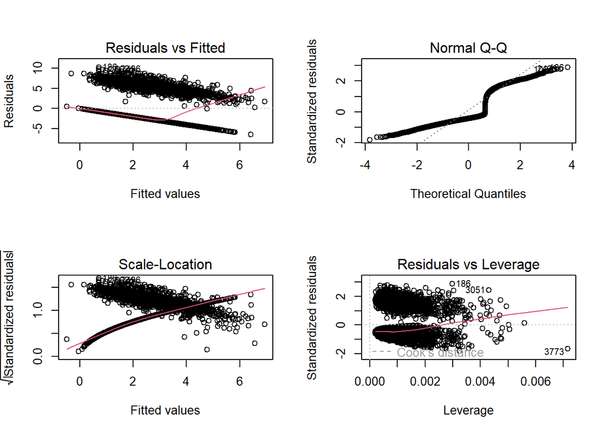

```r
# Generate diagnostic plots for model_1
par(mfrow = c(2, 2))  # Display 4 plots in a 2x2 layout
plot(model_1)
```

The linear regression model predicts the log-transformed crash cost (`TARGET_AMT_LOG`) using six predictors: `AGE`, `CAR_AGE`, `BLUEBOOK`, `KIDSDRIV_LOG`, `HOMEKIDS_LOG`, and `MVR_PTS`. All predictors are statistically significant, with `MVR_PTS` (traffic violations) showing the strongest positive association with crash costs, while `CAR_AGE` and `BLUEBOOK` have negative effects. The model explains 7.4% of the variance in crash costs, as indicated by the R-squared value, which is relatively low and suggests limited predictive strength. The residuals range from -6.402 to 10.166, indicating some large prediction errors, and the residual standard error is 3.528. While the F-statistic shows the model is statistically significant overall (p < 2.2e-16), the low R-squared and large residuals highlight its limited practical utility. Future improvements could include adding more predictors, testing for non-linear relationships, or using advanced modeling techniques. Further diagnostics, such as residual analysis and multicollinearity checks, are recommended to refine the model.

This diagnostic plot provides a detailed evaluation of the linear regression model through four key panels. The Residuals vs Fitted plot (top left) shows a curved pattern, indicating that the model does not adequately capture the relationship between the predictors and the target variable, violating the assumption of linearity. Additionally, the spread of residuals increases with fitted values, suggesting heteroscedasticity, where the variance of residuals is not constant. The Normal Q-Q plot (top right) shows deviations from the diagonal line, particularly at the tails, indicating that the residuals are not normally distributed. The Scale-Location plot (bottom left) reinforces the issue of heteroscedasticity, as the residual spread increases with fitted values, shown by the upward trend. Finally, the Residuals vs Leverage plot (bottom right) highlights potential influential observations with high leverage or large residuals, as indicated by points near or beyond Cook’s distance lines. Overall, these diagnostics suggest the need for model improvements, such as including non-linear terms, addressing heteroscedasticity, and handling influential data points.

In this model, we’ll use the log-transformed variables for better model stability, which should improve performance by addressing skewness in the data.

```r
summary(insurance_training$AGE)
```

```
##    Min. 1st Qu.  Median    Mean 3rd Qu.    Max.    NA's
##   16.00   39.00   45.00   44.79   51.00   81.00       6
```

```r
summary(insurance_training$CAR_AGE)
```

```
##    Min. 1st Qu.  Median    Mean 3rd Qu.    Max.    NA's
##  -3.000   1.000   8.000   8.328  12.000  28.000     510
```

```r
summary(insurance_training$KIDSDRIV)
```

```
##    Min. 1st Qu.  Median    Mean 3rd Qu.    Max.
##  0.0000  0.0000  0.0000  0.1711  0.0000  4.0000
```

```r
summary(insurance_training$HOMEKIDS)
```

```
##    Min. 1st Qu.  Median    Mean 3rd Qu.    Max.
##  0.0000  0.0000  0.0000  0.7212  1.0000  5.0000
```

```r
any(is.na(insurance_training$AGE))
```

```
## [1] TRUE
```

```r
any(is.na(insurance_training$CAR_AGE))
```

```
## [1] TRUE
```

```r
any(is.na(insurance_training$KIDSDRIV))
```

```
## [1] FALSE
```

```r
any(is.na(insurance_training$HOMEKIDS))
```

```
## [1] FALSE
```

```r
# Multiple Linear Regression - Model 2 (using log-transformed variables)
model2 <- lm(TARGET_AMT_LOG ~ AGE + CAR_AGE + KIDSDRIV_LOG + HOMEKIDS_LOG,
             data = insurance_training)
summary(model2)
```

```
##
## Call:
## lm(formula = TARGET_AMT_LOG ~ AGE + CAR_AGE + KIDSDRIV_LOG +
##     HOMEKIDS_LOG, data = insurance_training)
##
## Residuals:
##    Min     1Q Median     3Q    Max
## -4.163 -2.266 -1.777  4.235  9.515
##
## Coefficients:
##               Estimate Std. Error t value Pr(>|t|)
## (Intercept)   3.448441   0.270228  12.761  < 2e-16 ***
## AGE          -0.024091   0.005563  -4.330 1.51e-05 ***
## CAR_AGE      -0.049715   0.007401  -6.717 1.98e-11 ***
## KIDSDRIV_LOG  0.863174   0.167341   5.158 2.56e-07 ***
## HOMEKIDS_LOG  0.345093   0.100874   3.421 0.000627 ***
## ---
## Signif. codes:  0 '***' 0.001 '**' 0.01 '*' 0.05 '.' 0.1 ' ' 1
##
## Residual standard error: 3.618 on 7640 degrees of freedom
##   (516 observations deleted due to missingness)
## Multiple R-squared:  0.02637,    Adjusted R-squared:  0.02586
## F-statistic: 51.74 on 4 and 7640 DF,  p-value: < 2.2e-16
```

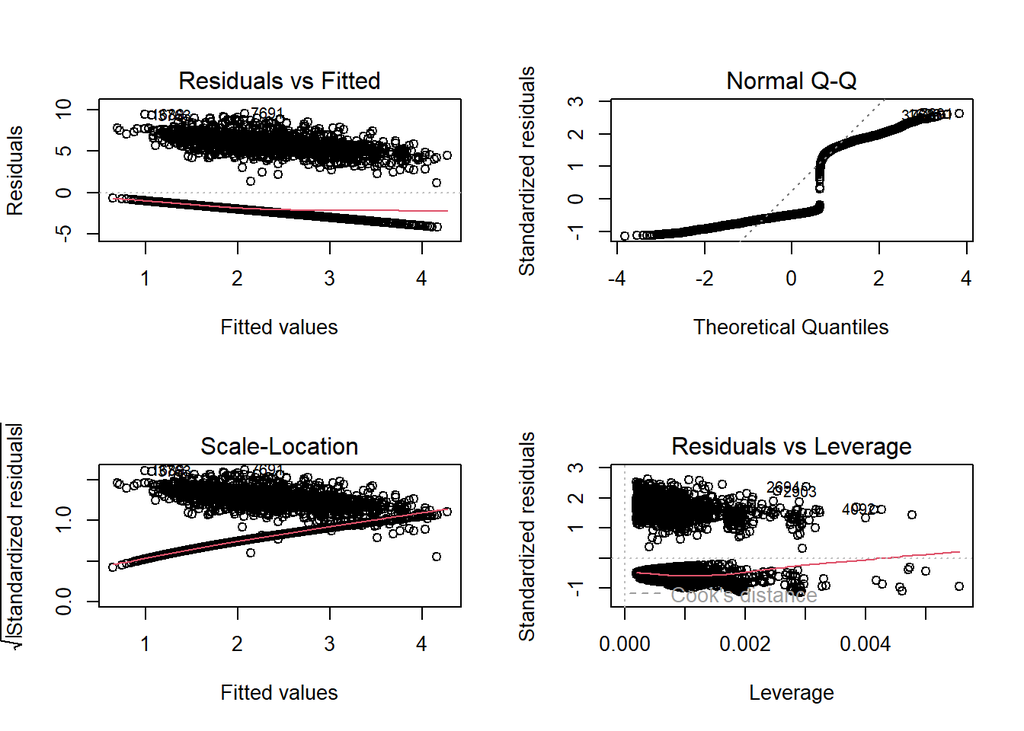

```r
# Generate diagnostic plots for model_1
par(mfrow = c(2, 2))  # Display 4 plots in a 2x2 layout
plot(model2)
```

The individual predictors (AGE, CAR_AGE, KIDSDRIV_LOG, and HOMEKIDS_LOG) are statistically significant and have the expected signs in terms of their effect on the target variable (TARGET_AMT_LOG).

The diagnostic plots provide insights into the assumptions of a regression model. The “Residuals vs Fitted” plot shows a slight curvature, indicating potential non-linearity or model misspecification. The “Normal Q-Q” plot highlights deviations at the tails, suggesting the residuals may not be normally distributed. The “Scale-Location” plot reveals a minor upward trend, which points to heteroscedasticity (non-constant variance of residuals). Finally, the “Residuals vs Leverage” plot identifies a few points near the Cook’s distance line, signaling potential influential observations that may unduly impact the model. These diagnostics suggest the need for model refinement, such as transformations, improved functional form, or addressing influential data points.

```r
# Multiple Linear Regression - Model 3 (including interaction terms)
model3 <- lm(TARGET_AMT_LOG ~ ., data = insurance_training)
summary(model3)
```

```
##
## Call:
## lm(formula = TARGET_AMT_LOG ~ ., data = insurance_training)
##
## Residuals:
##      Min       1Q   Median       3Q      Max
## -0.10154 -0.00825  0.00534  0.01203  0.61824
##
## Coefficients: (31 not defined because of singularities)
##                               Estimate Std. Error  t value Pr(>|t|)
## (Intercept)                 -9.693e+00  1.302e-01  -74.469   <2e-16 ***
## INDEX                        5.671e-07  2.446e-07    2.318   0.0205 *
## TARGET_FLAG                         NA         NA       NA       NA
## TARGET_AMT                  -5.850e-05  5.384e-07 -108.652   <2e-16 ***
## KIDSDRIV                     5.371e-02  7.057e-02    0.761   0.4467
## AGE                         -3.649e-04  1.802e-04   -2.024   0.0431 *
## HOMEKIDS                     8.554e-03  6.025e-03    1.420   0.1559
## YOJ                         -1.049e-04  2.106e-04   -0.498   0.6184
## INCOME                       1.613e-08  2.798e-08    0.577   0.5642
## PARENT1                     -8.934e-06  2.888e-03   -0.003   0.9975
## HOME_VAL                    -1.232e-08  8.673e-09   -1.421   0.1555
## MSTATUS                      1.069e-03  2.235e-03    0.478   0.6325
## SEX                          3.819e-03  2.251e-03    1.697   0.0899 .
## EDUCATION                    1.019e-03  4.778e-04    2.133   0.0331 *
## JOBClerical                  3.614e-03  4.123e-03    0.877   0.3809
## JOBDoctor                   -2.108e-03  6.893e-03   -0.306   0.7598
## JOBHome Maker                1.235e-03  4.945e-03    0.250   0.8028
## JOBLawyer                   -7.487e-03  4.316e-03   -1.735   0.0830 .
## JOBManager                  -6.952e-04  4.301e-03   -0.162   0.8716
## JOBProfessional              5.318e-03  3.855e-03    1.380   0.1679
## JOBStudent                   3.406e-03  4.654e-03    0.732   0.4643
## JOBz_Blue Collar             1.272e-03  3.669e-03    0.347   0.7288
## TRAVTIME                     7.656e-05  4.785e-05    1.600   0.1097
## CAR_USE                      1.066e-03  2.026e-03    0.526   0.5989
## BLUEBOOK                     2.809e-08  1.018e-07    0.276   0.7828
## TIF                         -1.681e-05  1.833e-04   -0.092   0.9269
## CAR_TYPE                     1.381e-04  4.770e-04    0.289   0.7723
## RED_CAR                     -4.394e-03  2.166e-03   -2.029   0.0426 *
## OLDCLAIM                    -1.930e-08  9.824e-08   -0.197   0.8442
## CLM_FREQ                     3.111e-04  6.850e-04    0.454   0.6497
```

[output cut: 39 more lines]

```
## TARGET_AMT_BOXCOX            6.457e+00  5.603e-02  115.249   <2e-16 ***
## TARGET_AMT_SQRT              3.143e-02  1.873e-04  167.780   <2e-16 ***
## KIDSDRIV_BOXCOX             -8.005e-01  1.245e+00   -0.643   0.5204
## KIDSDRIV_CUBE                       NA         NA       NA       NA
## AGE_GROUP31-50                      NA         NA       NA       NA
## AGE_GROUP51+                        NA         NA       NA       NA
## KIDSDRIV_RATIO              -7.440e-01  3.910e-01   -1.903   0.0572 .
## HOMEKIDS_RATIO              -1.259e-01  1.306e-01   -0.965   0.3349
## ---
## Signif. codes:  0 '***' 0.001 '**' 0.01 '*' 0.05 '.' 0.1 ' ' 1
##
## Residual standard error: 0.031 on 1844 degrees of freedom
##   (6271 observations deleted due to missingness)
## Multiple R-squared:  0.9985, Adjusted R-squared:  0.9985
## F-statistic: 2.798e+04 on 45 and 1844 DF,  p-value: < 2.2e-16
```

[figure not shown]

```r
# Generate diagnostic plots for model_1
par(mfrow = c(2, 2))  # Display 4 plots in a 2x2 layout
plot(model2)
```

This set of diagnostic plots evaluates the residuals of a regression model for key assumptions. The “Residuals vs Fitted” plot reveals a slight curvature, which may indicate non-linearity or a need to adjust the model. The “Normal Q-Q” plot shows deviations at the tails, suggesting that the residuals may not follow a normal distribution. The “Scale-Location” plot indicates a mild upward trend, hinting at heteroscedasticity, where the variance of residuals increases with fitted values. Lastly, the “Residuals vs Leverage” plot identifies some points near the Cook’s distance line, indicating potential influential observations that could unduly affect the model’s results. These findings suggest that the model might benefit from refinement, such as transformations, adjustments to the functional form, or addressing influential data points.

```r
set.seed(123)
# Model Development
log_model1 <- glm(TARGET_FLAG ~ AGE + CAR_AGE + KIDSDRIV_LOG + HOMEKIDS_LOG, data = insurance_training, family = 'binomial')
# Summary of the model
summary(log_model1)
```

```
##
## Call:
## glm(formula = TARGET_FLAG ~ AGE + CAR_AGE + KIDSDRIV_LOG + HOMEKIDS_LOG,
##     family = "binomial", data = insurance_training)
##
## Deviance Residuals:
##     Min       1Q   Median       3Q      Max
## -1.2226  -0.7972  -0.6914   1.3141   2.0749
##
## Coefficients:
##               Estimate Std. Error z value Pr(>|z|)
## (Intercept)  -0.187001   0.171895  -1.088  0.27665
## AGE          -0.016218   0.003577  -4.534 5.78e-06 ***
## CAR_AGE      -0.032916   0.004813  -6.838 8.01e-12 ***
## KIDSDRIV_LOG  0.486506   0.097387   4.996 5.86e-07 ***
## HOMEKIDS_LOG  0.196356   0.062052   3.164  0.00155 **
## ---
## Signif. codes:  0 '***' 0.001 '**' 0.01 '*' 0.05 '.' 0.1 ' ' 1
##
## (Dispersion parameter for binomial family taken to be 1)
##
##     Null deviance: 8800.1  on 7644  degrees of freedom
## Residual deviance: 8597.7  on 7640  degrees of freedom
##   (516 observations deleted due to missingness)
## AIC: 8607.7
##
## Number of Fisher Scoring iterations: 4
```

```r
# Deviance analyis
anova(log_model1, test = 'Chi') # use to ananlyse deviance in all variables
```

```
## Analysis of Deviance Table
##
## Model: binomial, link: logit
##
## Response: TARGET_FLAG
##
## Terms added sequentially (first to last)
##
##
##              Df Deviance Resid. Df Resid. Dev  Pr(>Chi)
## NULL                          7644     8800.1
## AGE           1   78.891      7643     8721.2 < 2.2e-16 ***
## CAR_AGE       1   55.414      7642     8665.8 9.764e-14 ***
## KIDSDRIV_LOG  1   58.124      7641     8607.7 2.461e-14 ***
## HOMEKIDS_LOG  1    9.918      7640     8597.7  0.001637 **
## ---
## Signif. codes:  0 '***' 0.001 '**' 0.01 '*' 0.05 '.' 0.1 ' ' 1
```

```r
# Odd Ratio
s <- c("AGE" , "CAR_AGE" , "KIDSDRIV_LOG" , "HOMEKIDS_LOG" )
or_log_model1 <- exp(coef(log_model1)[s])
print(or_log_model1)
```

```
##          AGE      CAR_AGE KIDSDRIV_LOG HOMEKIDS_LOG
##    0.9839132    0.9676196    1.6266223    1.2169603
```

```r
step_log_model1 <- step(log_model1, direction = 'backward')
```

```
## Start:  AIC=8607.75
## TARGET_FLAG ~ AGE + CAR_AGE + KIDSDRIV_LOG + HOMEKIDS_LOG
##
##                Df Deviance    AIC
## <none>              8597.7 8607.7
## - HOMEKIDS_LOG  1   8607.7 8615.7
## - AGE           1   8618.5 8626.5
## - KIDSDRIV_LOG  1   8622.5 8630.5
## - CAR_AGE       1   8645.2 8653.2
```

```r
summary(step_log_model1)
```

```
##
## Call:
## glm(formula = TARGET_FLAG ~ AGE + CAR_AGE + KIDSDRIV_LOG + HOMEKIDS_LOG,
##     family = "binomial", data = insurance_training)
##
## Deviance Residuals:
##     Min       1Q   Median       3Q      Max
## -1.2226  -0.7972  -0.6914   1.3141   2.0749
##
## Coefficients:
##               Estimate Std. Error z value Pr(>|z|)
## (Intercept)  -0.187001   0.171895  -1.088  0.27665
## AGE          -0.016218   0.003577  -4.534 5.78e-06 ***
## CAR_AGE      -0.032916   0.004813  -6.838 8.01e-12 ***
## KIDSDRIV_LOG  0.486506   0.097387   4.996 5.86e-07 ***
## HOMEKIDS_LOG  0.196356   0.062052   3.164  0.00155 **
## ---
## Signif. codes:  0 '***' 0.001 '**' 0.01 '*' 0.05 '.' 0.1 ' ' 1
##
## (Dispersion parameter for binomial family taken to be 1)
##
##     Null deviance: 8800.1  on 7644  degrees of freedom
## Residual deviance: 8597.7  on 7640  degrees of freedom
##   (516 observations deleted due to missingness)
## AIC: 8607.7
##
## Number of Fisher Scoring iterations: 4
```

```r
exp(coef(log_model1)[s])/(1 + exp(coef(log_model1)[s]))
```

```
##          AGE      CAR_AGE KIDSDRIV_LOG HOMEKIDS_LOG
##    0.4959457    0.4917717    0.6192829    0.5489319
```

```r
# Logit model average means  effects
log_model1_scalar  <- mean(dlogis(predict(log_model1, type = 'link')))
log_model1_scalar * coef(log_model1)
```

```
##  (Intercept)          AGE      CAR_AGE KIDSDRIV_LOG HOMEKIDS_LOG
## -0.035214013 -0.003053925 -0.006198435  0.091613569  0.036975716
```

The results of the **Analysis of Deviance Table** provide insight into how each variable contributes to reducing the deviance of the model sequentially, which measures the model’s goodness-of-fit. The null model, with no predictors, starts with a residual deviance of **8800.1** on **7644 degrees of freedom (Df)**.

1. **AGE**: Adding this variable reduces the deviance by **78.891**, leaving a residual deviance of **8721.2** with **7643 Df**. This reduction is highly significant ($p < 2.2 \times 10^{-16}$), indicating that AGE is a crucial predictor in the model.
2. **CAR_AGE**: Adding CAR_AGE further reduces the deviance by **55.414**, resulting in a residual deviance of **8665.8** with **7642 Df**. This reduction is also highly significant ($p = 9.764 \times 10^{-14}$), confirming its importance in explaining variability in TARGET_FLAG.
3. **KIDSDRIV_LOG**: Including KIDSDRIV_LOG decreases the deviance by **58.124**, leaving a residual deviance of **8607.7** on **7641 Df**. This variable is also a significant contributor ($p = 2.461 \times 10^{-14}$) to the model.
4. **HOMEKIDS_LOG**: Adding this variable reduces the deviance by **9.918**, resulting in the final residual deviance of **8597.7** with **7640 Df**. Although this reduction is less pronounced compared to the other variables, it is still statistically significant ($p = 0.001637$).

Each variable in the model significantly reduces the deviance, with AGE, CAR_AGE, and KIDSDRIV_LOG making the most substantial contributions. HOMEKIDS_LOG has a smaller but still meaningful impact. The deviance reductions confirm that all these predictors play an important role in explaining the likelihood of TARGET_FLAG (car crashes).

The odds ratios derived from the logistic regression model $m1$ provide insights into the relationship between the predictor variables and the likelihood of a car being in a crash ($TARGET\_FLAG = 1$). For the variable `AGE`, the odds ratio of 0.9839 indicates that for each one-year increase in the driver’s age, the odds of being in a crash decrease by approximately 1.6%, suggesting that younger drivers may exhibit riskier behavior compared to older, more experienced drivers. Similarly, for `CAR_AGE`, the odds ratio of 0.9676 implies that for every additional year in the car’s age, the odds of a crash decrease by about 3.2%, potentially because older cars may be driven less frequently or more cautiously. In contrast, the variable `KIDSDRIV_LOG` has an odds ratio of 1.6266, indicating that for every unit increase in the log-transformed number of teenage drivers in the household, the odds of a crash increase by approximately 62.7%, reflecting the higher risk associated with teenage drivers due to their inexperience. Lastly, `HOMEKIDS_LOG` shows an odds ratio of 1.2170, meaning that for every unit increase in the log-transformed number of children in the household, the odds of a crash increase by 21.7%, possibly due to the increased driving frequency or busier schedules in larger households. These findings highlight the varying impacts of demographic and vehicle-related factors on crash likelihood.

AGE and CAR_AGE both have a negative relationship with the probability of TARGET_FLAG = 1, meaning as age and car age increase, the likelihood of the target outcome decreases.

KIDSDRIV_LOG and HOMEKIDS_LOG both have positive relationships with the target outcome, meaning that as these variables increase, the likelihood of TARGET_FLAG = 1 increases.

The model’s fit is acceptable, but there is room for improvement, as indicated by the residual deviance and AIC.

```r
# Apply log transformation to variables in the evaluation dataset
insurance_evaluation$KIDSDRIV_LOG <- log(insurance_evaluation$KIDSDRIV + 1)
insurance_evaluation$HOMEKIDS_LOG <- log(insurance_evaluation$HOMEKIDS + 1)
```

#### 3.2.2 Model 2: Including Interaction Terms

We include interaction terms to explore the effect of variable combinations on the target variable.

```r
# Logistic Regression - Model 3 (including interaction terms + KIDSDRIV_RATIO)
log_model2 <- glm(TARGET_FLAG ~ AGE * CAR_AGE + KIDSDRIV_RATIO + HOMEKIDS_LOG,
                  family = binomial(link = "probit"), data = insurance_training)
summary(log_model2)
```

```
##
## Call:
## glm(formula = TARGET_FLAG ~ AGE * CAR_AGE + KIDSDRIV_RATIO +
##     HOMEKIDS_LOG, family = binomial(link = "probit"), data = insurance_training)
##
## Deviance Residuals:
##     Min       1Q   Median       3Q      Max
## -1.2608  -0.7945  -0.6926   1.3213   2.0013
##
## Coefficients:
##                  Estimate Std. Error z value Pr(>|z|)
## (Intercept)    -0.0880299  0.1537950  -0.572 0.567062
## AGE            -0.0106527  0.0033490  -3.181 0.001468 **
## CAR_AGE        -0.0320561  0.0150532  -2.130 0.033212 *
## KIDSDRIV_RATIO  6.0594022  1.3994757   4.330 1.49e-05 ***
## HOMEKIDS_LOG    0.1388881  0.0365864   3.796 0.000147 ***
## AGE:CAR_AGE     0.0002765  0.0003277   0.844 0.398757
## ---
## Signif. codes:  0 '***' 0.001 '**' 0.01 '*' 0.05 '.' 0.1 ' ' 1
##
## (Dispersion parameter for binomial family taken to be 1)
##
##     Null deviance: 8800.1  on 7644  degrees of freedom
## Residual deviance: 8602.7  on 7639  degrees of freedom
##   (516 observations deleted due to missingness)
## AIC: 8614.7
##
## Number of Fisher Scoring iterations: 4
```

```r
# Odd Ratio
s2 <- c("AGE"  , "CAR_AGE" , "KIDSDRIV_RATIO " , "HOMEKIDS_LOG" )
or_m2 <- exp(coef(log_model2)[s2])
print(or_m2)
```

```
##          AGE      CAR_AGE         <NA> HOMEKIDS_LOG
##    0.9894038    0.9684523           NA    1.1489956
```

```r
step_m2 <- step(log_model2, direction = 'backward')
```

```
## Start:  AIC=8614.73
## TARGET_FLAG ~ AGE * CAR_AGE + KIDSDRIV_RATIO + HOMEKIDS_LOG
##
##                  Df Deviance    AIC
## - AGE:CAR_AGE     1   8603.5 8613.5
## <none>                8602.7 8614.7
## - HOMEKIDS_LOG    1   8617.1 8627.1
## - KIDSDRIV_RATIO  1   8621.5 8631.5
##
## Step:  AIC=8613.48
## TARGET_FLAG ~ AGE + CAR_AGE + KIDSDRIV_RATIO + HOMEKIDS_LOG
##
##                  Df Deviance    AIC
## <none>                8603.5 8613.5
## - HOMEKIDS_LOG    1   8618.4 8626.4
## - AGE             1   8620.4 8628.4
## - KIDSDRIV_RATIO  1   8621.9 8629.9
## - CAR_AGE         1   8651.9 8659.9
```

```r
summary(step_m2)
```

```
##
## Call:
## glm(formula = TARGET_FLAG ~ AGE + CAR_AGE + KIDSDRIV_RATIO +
##     HOMEKIDS_LOG, family = binomial(link = "probit"), data = insurance_training)
##
## Deviance Residuals:
##     Min       1Q   Median       3Q      Max
## -1.2555  -0.7985  -0.6939   1.3274   2.0745
##
## Coefficients:
##                 Estimate Std. Error z value Pr(>|z|)
## (Intercept)    -0.186212   0.101091  -1.842 0.065472 .
## AGE            -0.008441   0.002092  -4.035 5.45e-05 ***
## CAR_AGE        -0.019569   0.002824  -6.930 4.21e-12 ***
## KIDSDRIV_RATIO  5.994630   1.396946   4.291 1.78e-05 ***
## HOMEKIDS_LOG    0.141045   0.036486   3.866 0.000111 ***
## ---
## Signif. codes:  0 '***' 0.001 '**' 0.01 '*' 0.05 '.' 0.1 ' ' 1
##
## (Dispersion parameter for binomial family taken to be 1)
##
##     Null deviance: 8800.1  on 7644  degrees of freedom
## Residual deviance: 8603.5  on 7640  degrees of freedom
##   (516 observations deleted due to missingness)
## AIC: 8613.5
##
## Number of Fisher Scoring iterations: 4
```

```r
exp(coef(log_model2)[s2])/(1 + exp(coef(log_model2)[s2]))
```

```
##          AGE      CAR_AGE         <NA> HOMEKIDS_LOG
##    0.4973369    0.4919867           NA    0.5346663
```

```r
# Mean average margibal effect
exp(coef(log_model2)[s2])/(1 + exp(coef(log_model2)[s2]))
```

```
##          AGE      CAR_AGE         <NA> HOMEKIDS_LOG
##    0.4973369    0.4919867           NA    0.5346663
```

```r
m2_probit_scalar <- mean(dnorm(predict(log_model2, type = 'link')))
m2_probit_scalar * coef(log_model2)
```

```
##    (Intercept)            AGE        CAR_AGE KIDSDRIV_RATIO   HOMEKIDS_LOG
##  -2.800403e-02  -3.388834e-03  -1.019766e-02   1.927615e+00   4.418306e-02
##    AGE:CAR_AGE
##   8.795838e-05
```

#### 3.2.2 Model 2: Including Interaction Terms

We include interaction terms to explore the effect of variable combinations on the target variable.

```r
# Logistic Regression - Model 3 (including interaction terms + KIDSDRIV_RATIO)
log_model2 <- glm(TARGET_FLAG ~ AGE * CAR_AGE + KIDSDRIV_RATIO + HOMEKIDS_LOG,
                  family = binomial(link = "logit"), data = insurance_training)
summary(log_model2)
```

```
##
## Call:
## glm(formula = TARGET_FLAG ~ AGE * CAR_AGE + KIDSDRIV_RATIO +
##     HOMEKIDS_LOG, family = binomial(link = "logit"), data = insurance_training)
##
## Deviance Residuals:
##     Min       1Q   Median       3Q      Max
## -1.2631  -0.7937  -0.6928   1.3204   2.0072
##
## Coefficients:
##                  Estimate Std. Error z value Pr(>|z|)
## (Intercept)    -0.1148933  0.2560257  -0.449 0.653607
## AGE            -0.0179099  0.0056046  -3.196 0.001396 **
## CAR_AGE        -0.0491942  0.0255384  -1.926 0.054069 .
## KIDSDRIV_RATIO  9.8363082  2.2736765   4.326 1.52e-05 ***
## HOMEKIDS_LOG    0.2255004  0.0609396   3.700 0.000215 ***
## AGE:CAR_AGE     0.0003663  0.0005596   0.655 0.512709
## ---
## Signif. codes:  0 '***' 0.001 '**' 0.01 '*' 0.05 '.' 0.1 ' ' 1
##
## (Dispersion parameter for binomial family taken to be 1)
##
##     Null deviance: 8800.1  on 7644  degrees of freedom
## Residual deviance: 8603.7  on 7639  degrees of freedom
##   (516 observations deleted due to missingness)
## AIC: 8615.7
##
## Number of Fisher Scoring iterations: 4
```

The significant predictors in this model are AGE, KIDSDRIV_RATIO, and HOMEKIDS_LOG, indicating they are important in predicting the outcome (TARGET_FLAG).

The model is not greatly improved by the interaction term (AGE:CAR_AGE), suggesting that there is no strong interaction effect between AGE and CAR_AGE.

The CAR_AGE predictor is marginally significant, suggesting a potential relationship, but it is not as strong as the other variables.

#### 3.3.2 Model 3: Including Interaction Terms+ Other

```r
# Logistic Regression - Model 3 (Including Interaction Terms + KIDSDRIV_RATIO)
log_model3 <- glm(TARGET_FLAG ~ AGE * CAR_AGE + KIDSDRIV_RATIO + HOMEKIDS_LOG,
                          family = binomial(link = "logit"), data = insurance_training)
summary(log_model3)
```

```
##
## Call:
## glm(formula = TARGET_FLAG ~ AGE * CAR_AGE + KIDSDRIV_RATIO +
##     HOMEKIDS_LOG, family = binomial(link = "logit"), data = insurance_training)
##
## Deviance Residuals:
##     Min       1Q   Median       3Q      Max
## -1.2631  -0.7937  -0.6928   1.3204   2.0072
##
## Coefficients:
##                  Estimate Std. Error z value Pr(>|z|)
## (Intercept)    -0.1148933  0.2560257  -0.449 0.653607
## AGE            -0.0179099  0.0056046  -3.196 0.001396 **
## CAR_AGE        -0.0491942  0.0255384  -1.926 0.054069 .
## KIDSDRIV_RATIO  9.8363082  2.2736765   4.326 1.52e-05 ***
## HOMEKIDS_LOG    0.2255004  0.0609396   3.700 0.000215 ***
## AGE:CAR_AGE     0.0003663  0.0005596   0.655 0.512709
## ---
## Signif. codes:  0 '***' 0.001 '**' 0.01 '*' 0.05 '.' 0.1 ' ' 1
##
## (Dispersion parameter for binomial family taken to be 1)
##
##     Null deviance: 8800.1  on 7644  degrees of freedom
## Residual deviance: 8603.7  on 7639  degrees of freedom
##   (516 observations deleted due to missingness)
## AIC: 8615.7
##
## Number of Fisher Scoring iterations: 4
```

CAR_AGE has a weaker, marginally significant effect, while HOMEKIDS_LOG also contributes significantly to the model.

The interaction between AGE and CAR_AGE does not significantly improve the model.

## 4. SELECT MODELS

In this section, we will evaluate the multiple linear regression and binary logistic regression models using various criteria. The goal is to select the models that provide the best balance between performance and interpretability, while also considering the business context and model simplicity. Here, we will explain the criteria used to select the best models, address potential issues such as multi-collinearity, and discuss the relevant model outputs.

### 4.1 Compare Coefficients:

The key objective for the multiple linear regression model is to find the best model that explains the variability in the target variable (TARGET_AMT_LOG).

Let’s extract Coefficients and Standard Errors:

```r
# Model Evaluation for Multiple Linear Regression - Model 1
# Check for multicollinearity (VIF)
vif(model_1)  # Variance Inflation Factor (VIF)
```

```
##          AGE      CAR_AGE     BLUEBOOK KIDSDRIV_LOG HOMEKIDS_LOG      MVR_PTS
##     1.367368     1.067987     1.058281     1.355539     1.736877     1.009238
```

```r
# Calculate R-squared, Adjusted R-squared, RMSE, and F-statistic
summary(model_1)
```

```
##
## Call:
## lm(formula = TARGET_AMT_LOG ~ AGE + CAR_AGE + BLUEBOOK + KIDSDRIV_LOG +
##     HOMEKIDS_LOG + MVR_PTS, data = insurance_training)
##
## Residuals:
##    Min     1Q Median     3Q    Max
## -6.402 -2.246 -1.508  3.252 10.166
##
## Coefficients:
##                Estimate Std. Error t value Pr(>|t|)
## (Intercept)   2.837e+00  2.707e-01  10.482  < 2e-16 ***
## AGE          -1.564e-02  5.462e-03  -2.863  0.00421 **
## CAR_AGE      -4.307e-02  7.315e-03  -5.887 4.09e-09 ***
## BLUEBOOK     -2.588e-05  4.942e-06  -5.237 1.68e-07 ***
## KIDSDRIV_LOG  7.758e-01  1.633e-01   4.752 2.05e-06 ***
## HOMEKIDS_LOG  2.967e-01  9.841e-02   3.015  0.00258 **
## MVR_PTS       3.599e-01  1.888e-02  19.060  < 2e-16 ***
## ---
## Signif. codes:  0 '***' 0.001 '**' 0.01 '*' 0.05 '.' 0.1 ' ' 1
##
## Residual standard error: 3.528 on 7638 degrees of freedom
##   (516 observations deleted due to missingness)
## Multiple R-squared:  0.07448,    Adjusted R-squared:  0.07375
## F-statistic: 102.4 on 6 and 7638 DF,  p-value: < 2.2e-16
```

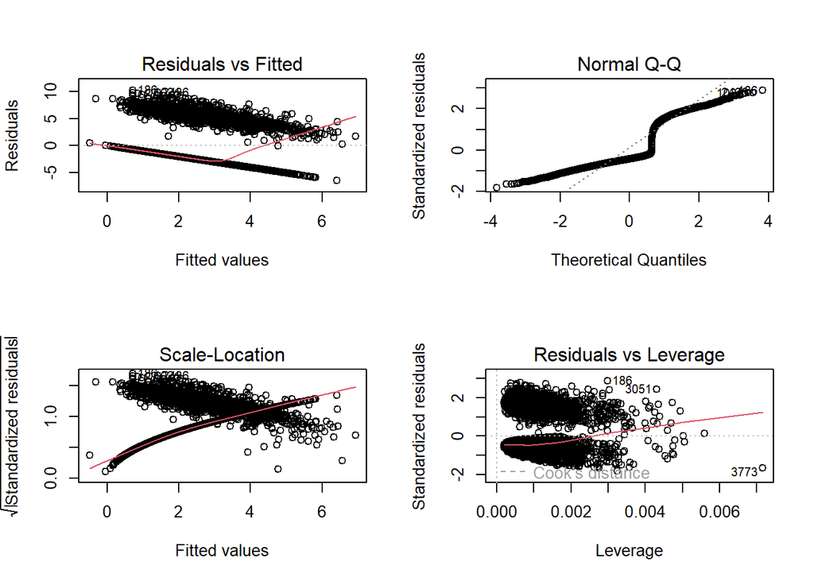

```r
# Plot residuals
par(mfrow = c(2, 2))
plot(model_1)
```

```r
# RMSE Calculation
rmse_model1 <- sqrt(mean(model_1$residuals^2))

# Display results
cat("Adjusted R^2: ", summary(model_1)$adj.r.squared, "\n")
```

```
## Adjusted R^2:  0.07374798
```

```r
cat("RMSE: ", rmse_model1, "\n")
```

```
## RMSE:  3.52669
```

```r
cat("F-statistic: ", summary(model_1)$fstatistic[1], "\n")
```

```
## F-statistic:  102.4356
```

The model appears to have statistically significant predictors (with very low p-values), but the overall fit is poor as indicated by the low R-squared and adjusted R-squared values. This suggests that while individual predictors like age, car age, and home kids may have a significant relationship with the target variable, the model is not explaining much of the variability in the target variable. Further model refinement or additional predictors may be necessary for a better fit.